# Transit_ridership_analysis

10/2/2019

# Load and organize transit ridership and stop locations data

# Transit ridership comparisons

There are four comparisons.

## average total weekday boardings at all bus stops and rail stations within the experimental and control corridors

The ridership of the MAX Orange Line accouts for the most of the increase in ridership.

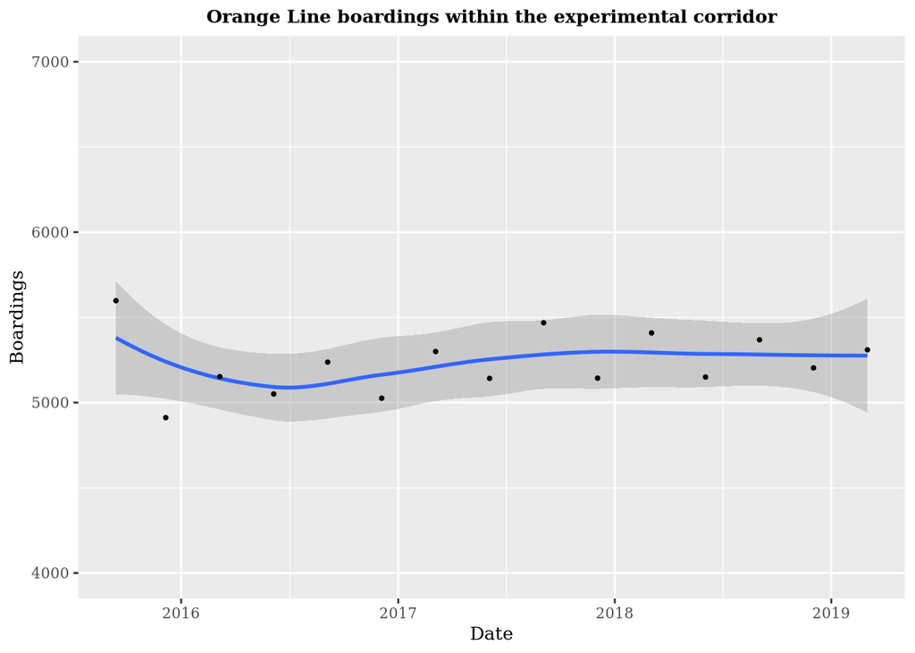

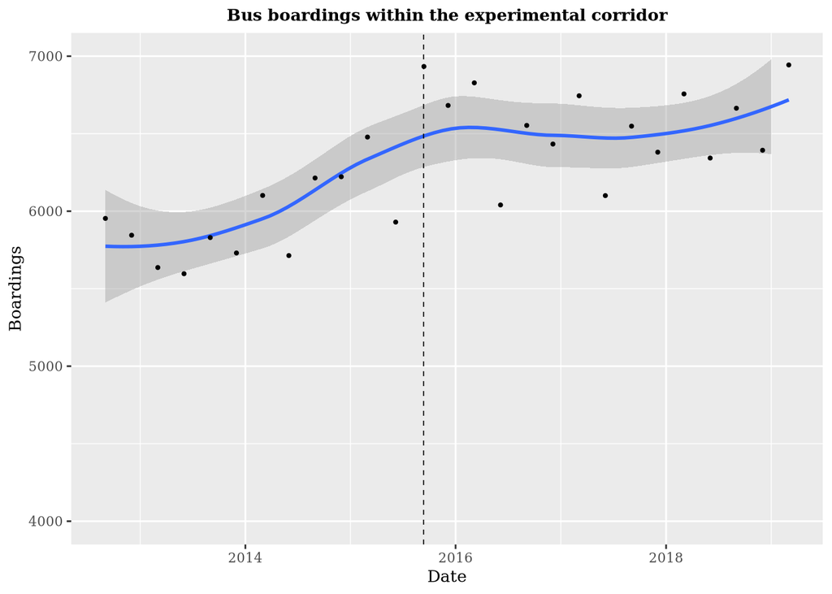

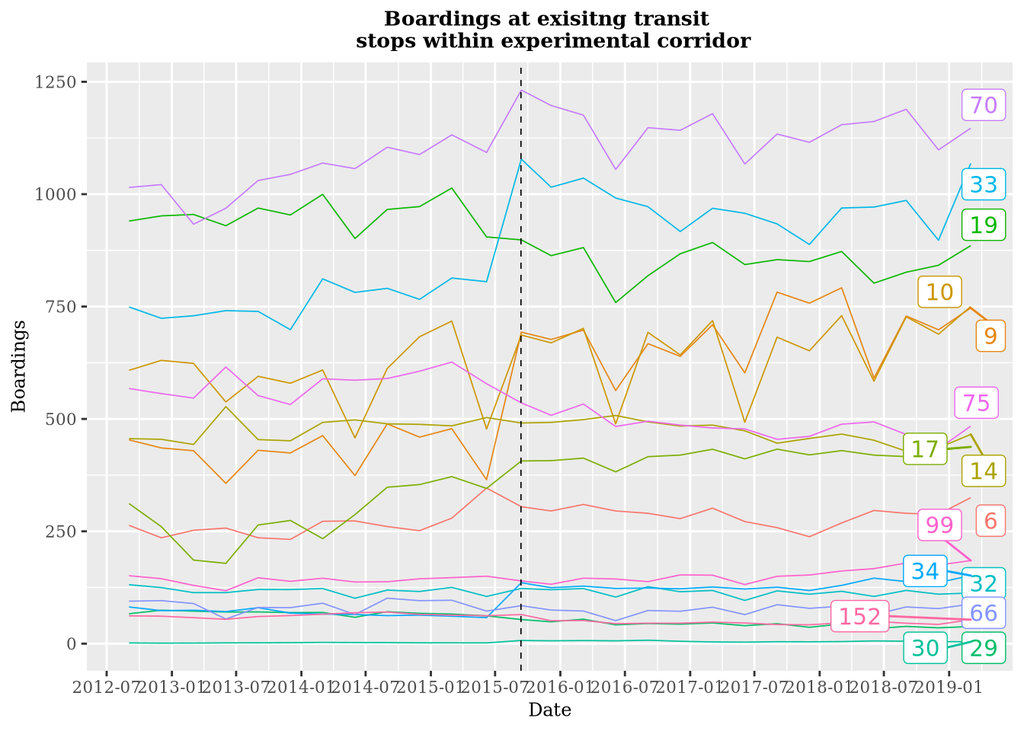

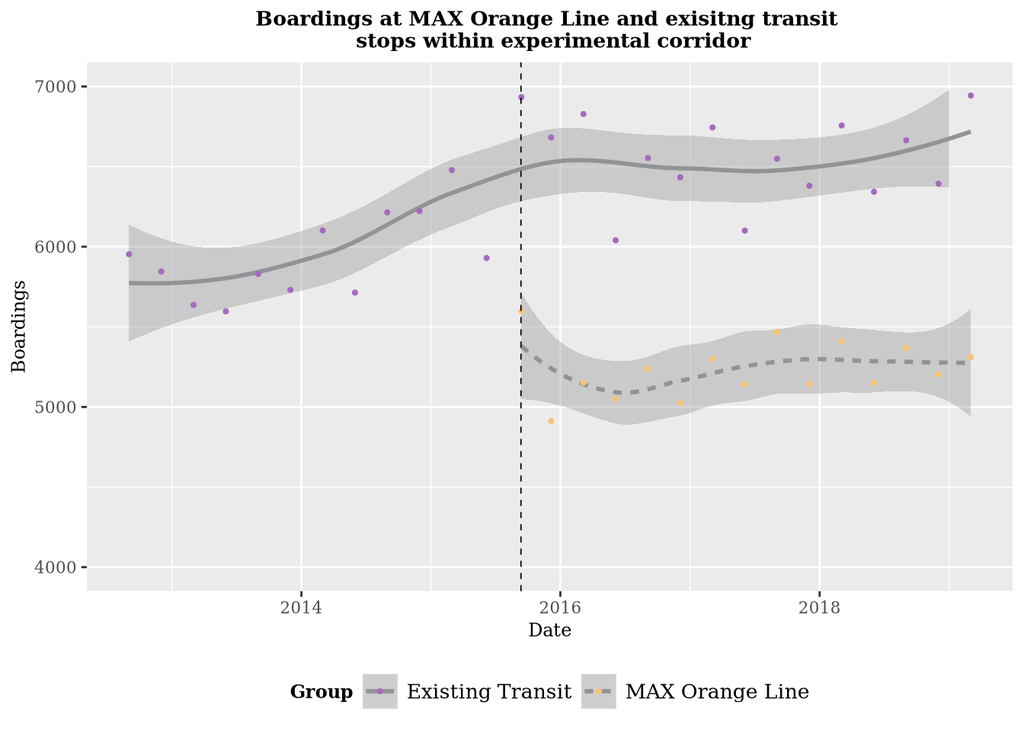

Transit ridership decreased within the control corridor after the operation of the MAX Orange Line.

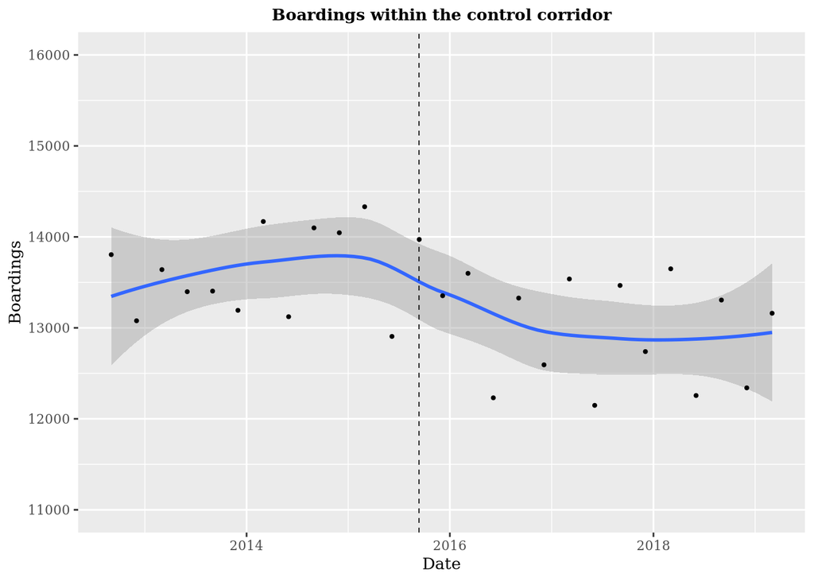

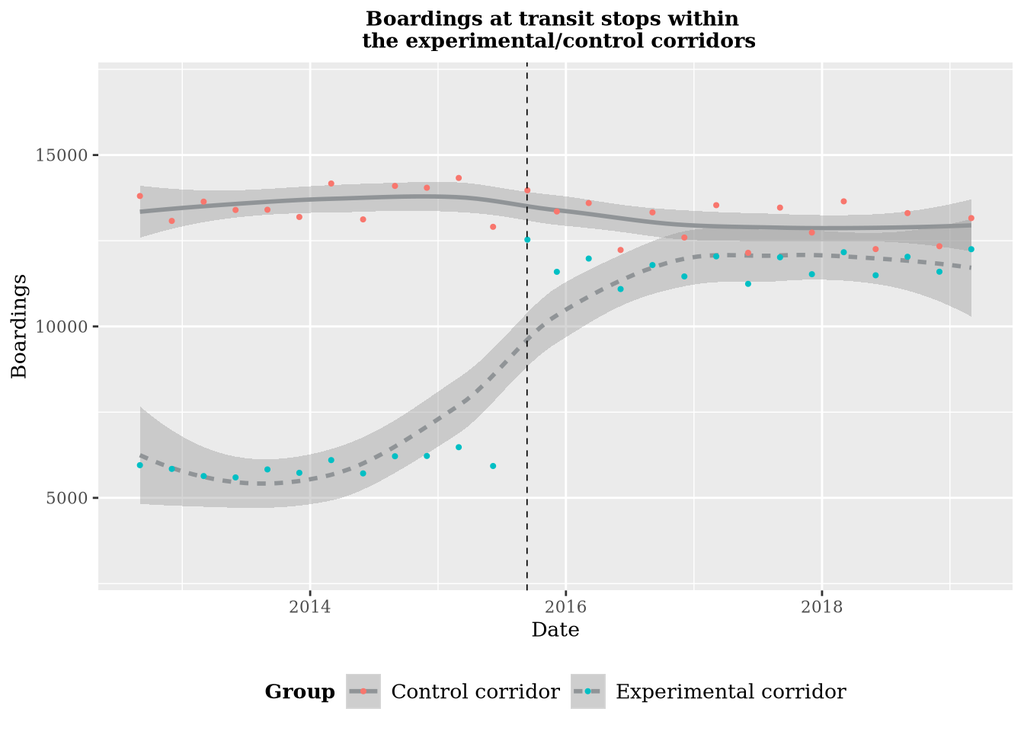

### DID regression analysis

```
##
## Ridership base and multiple time priods
## ==============================================================================
##                                                  Dependent variable:
##                                         --------------------------------------
##                                                       Boardings
##                                            Base model     Multiple time priods
##                                                (1)                (2)
## ------------------------------------------------------------------------------
## Before_after                               -554.000***
##                                             (179.000)
##
## GroupExperimental corridor                -7,662.000***      -7,662.000***
##                                             (189.000)          (196.000)
##
## Before_after:GroupExperimental corridor   6,404.000***
##                                             (254.000)
##
## Year_1st                                                        -310.000
##                                                                (278.000)
##
## Year_2nd                                                       -698.000**
##                                                                (278.000)
##
## Year_3rd                                                       -572.000**
##                                                                (278.000)
##
## Year_4th                                                       -664.000**
##                                                                (310.000)
##
## GroupExperimental corridor:Year_1st                           6,172.000***
##                                                                (393.000)
##
## GroupExperimental corridor:Year_2nd                           6,394.000***
##                                                                (393.000)
##
## GroupExperimental corridor:Year_3rd                           6,434.000***
##                                                                (393.000)
##
## GroupExperimental corridor:Year_4th                           6,687.000***
##                                                                (439.000)
##
## Constant                                  13,599.000***      13,599.000***
##                                             (134.000)          (139.000)
##
## ------------------------------------------------------------------------------
## Observations                                   54                  54
## R2                                            0.977              0.978
## Adjusted R2                                   0.976              0.974
## Residual Std. Error                     463.000 (df = 50)  481.000 (df = 44)
## ==============================================================================
## Note:                                              *p<0.1; **p<0.05; ***p<0.01
```

### Plots for results

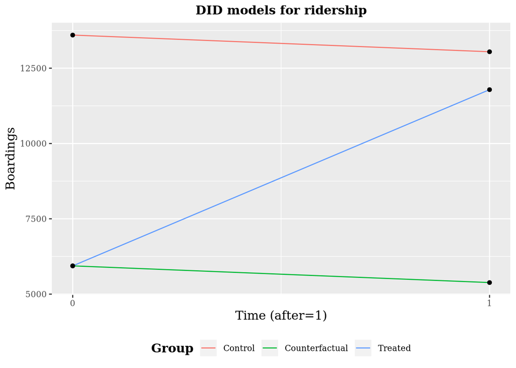

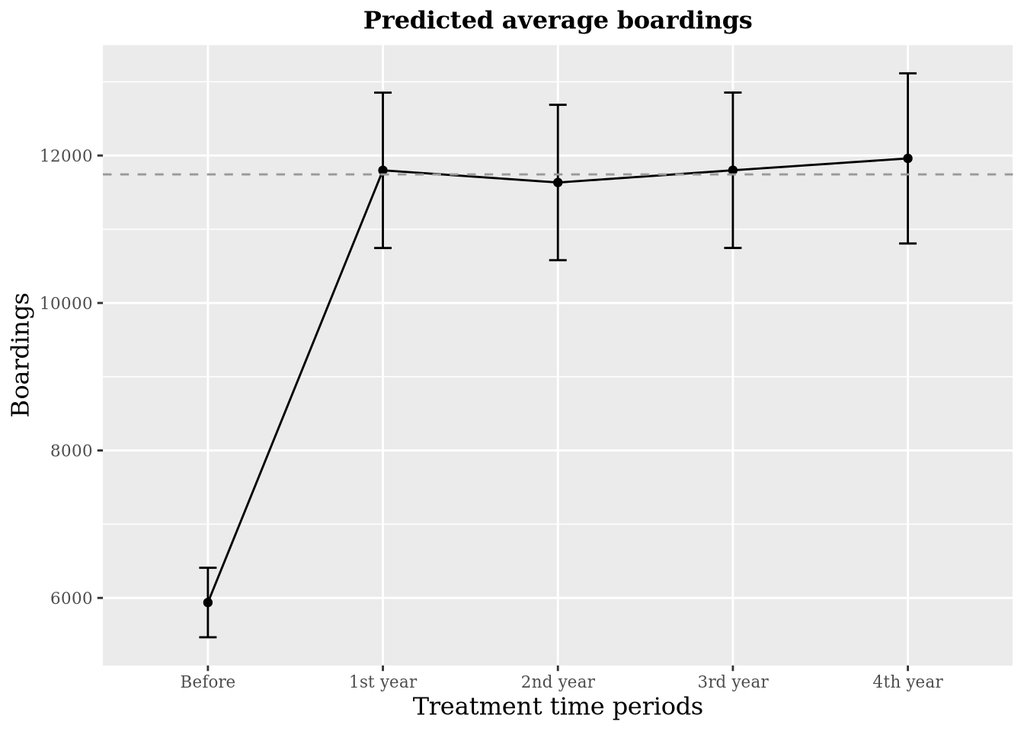

## compared changes in average total weekday ridership of east–west transit lines within the study area

Experimental: Routes 19, 30, 70, 291 cross the screenline  
Control: East-west route 9, 17 cross the screenliens

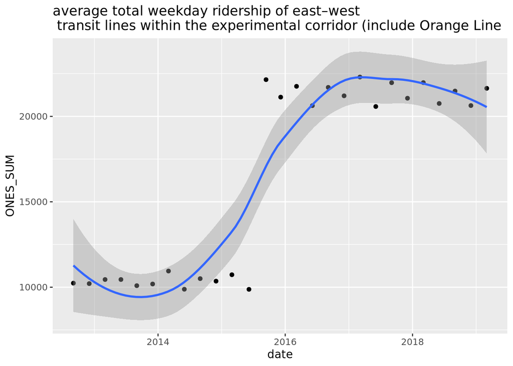

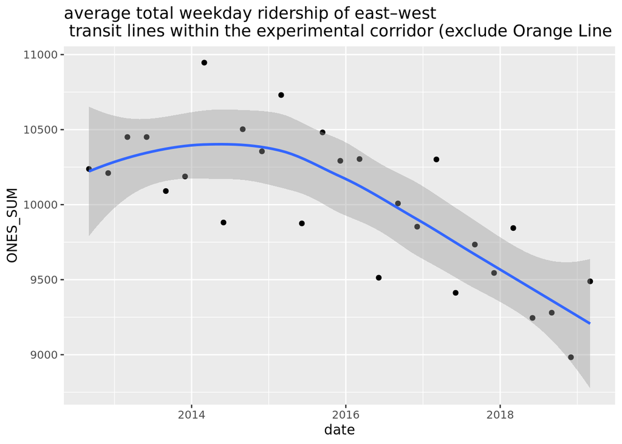

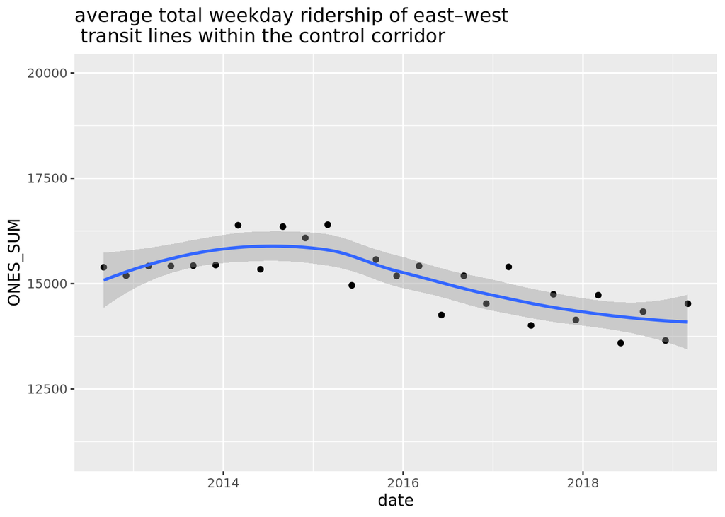

## Weekday peak-period (AM and PM peaks combined) bidirectional person throughput by east–west Metro bus and rail lines across the same screenlines, before and after.

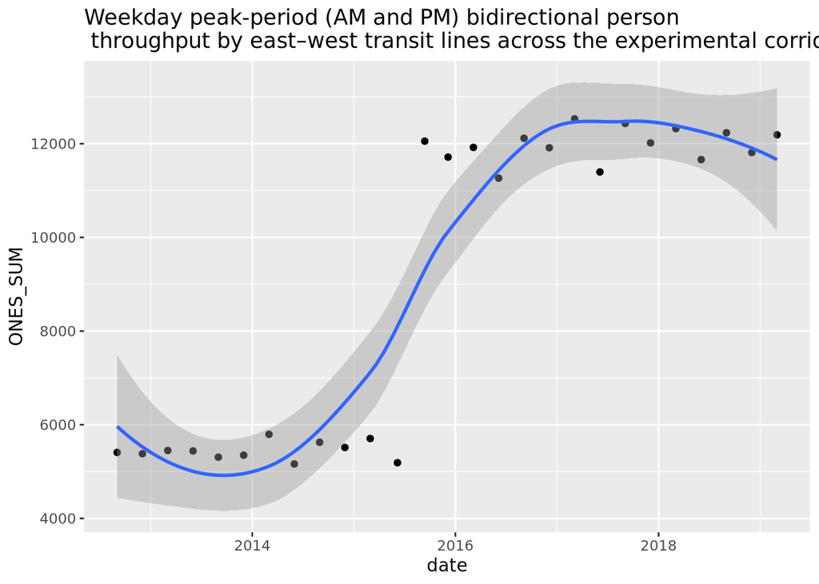

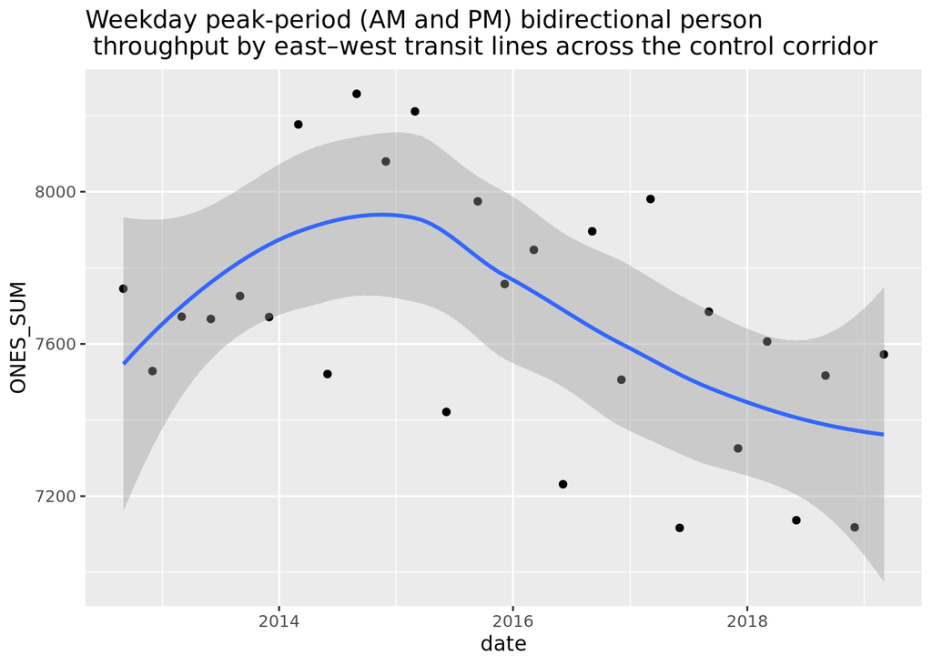

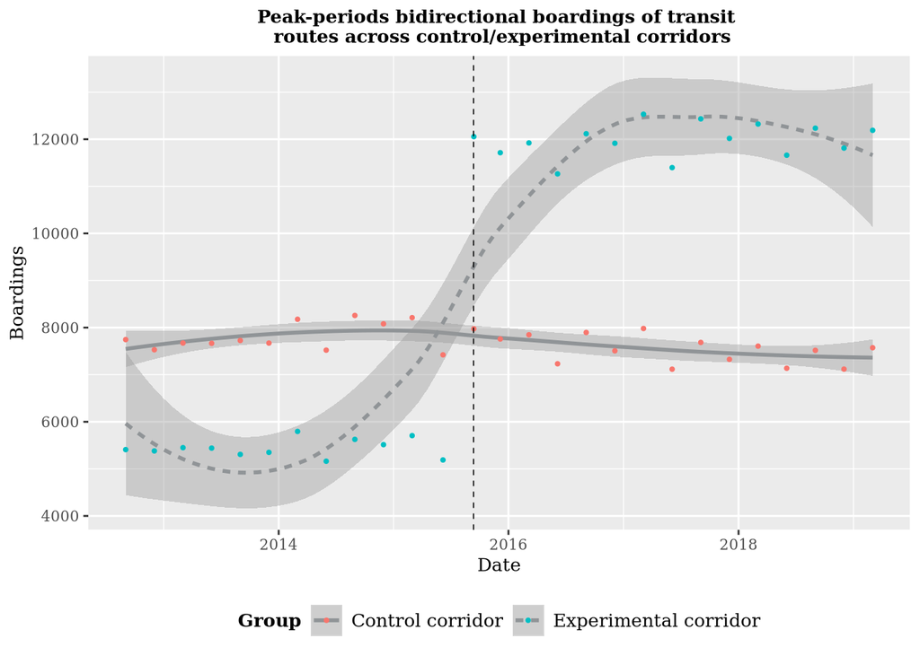

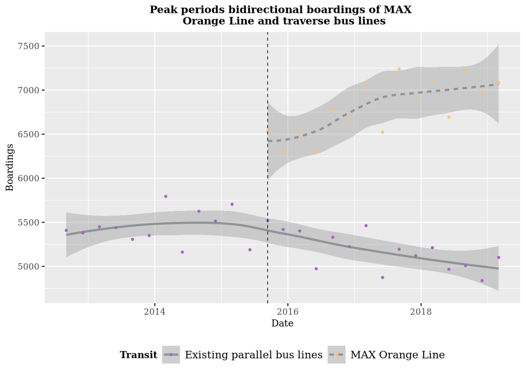

## Boardings and alightings at specific bus stops within a quarter-mile walking radius of MAX Orange Line stations.

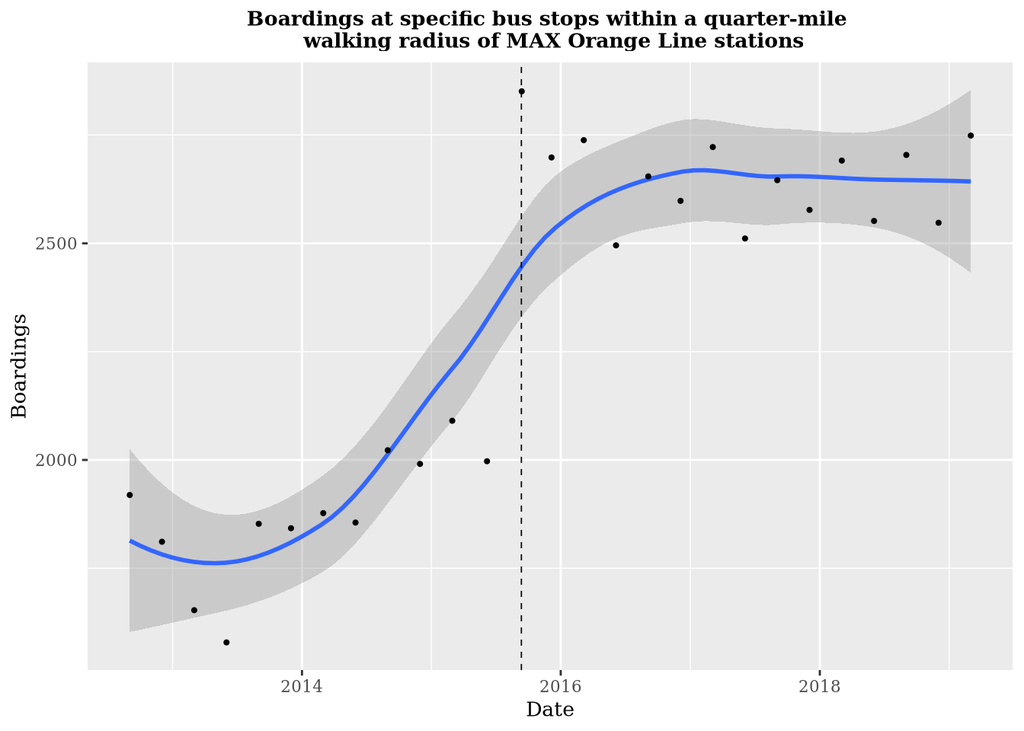

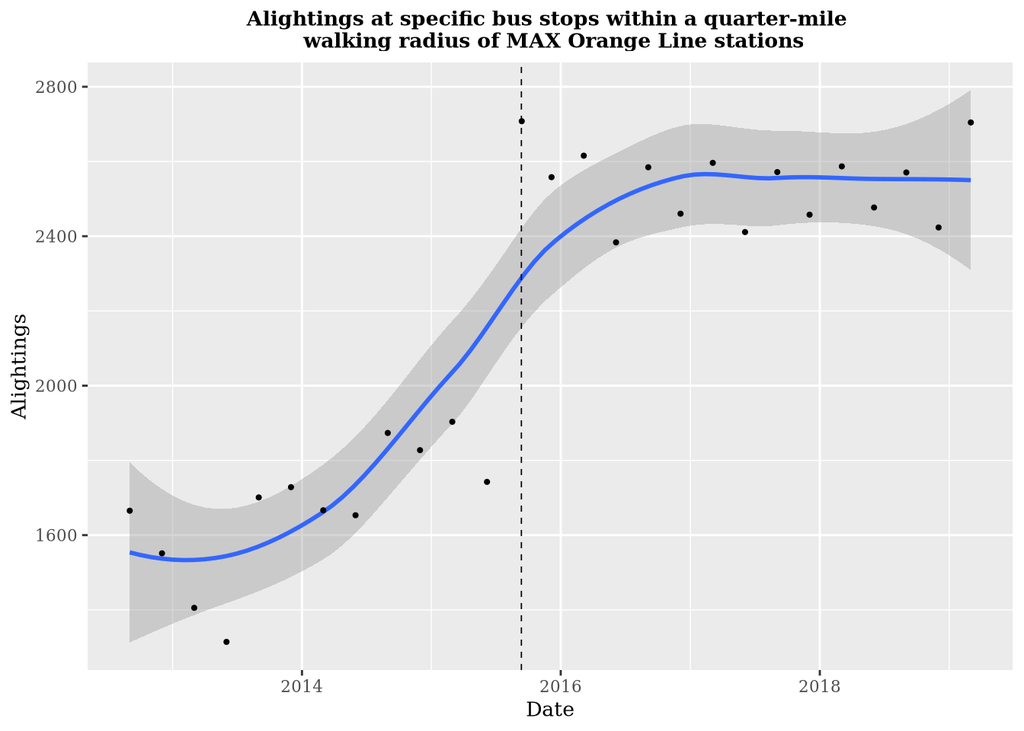